# Kiruthikaa California Housing Price Prediction

**Author:** Kiruthikaa **Date:** 10/23/2025 **Objective:** Predict the median house price in California using available housing features.

## Introduction

In this lab, we explore the California Housing dataset to uncover patterns that influence home values across the state. By focusing on features like median income and average room count, we build a linear regression model to estimate median house prices. The workflow includes data exploration, visualization, model training, and performance evaluation using R², MAE, and RMSE. This project demonstrates how statistical learning can turn raw housing data into actionable insights, a foundational skill for data-driven decision-making in real estate and urban planning.

## Imports

In the code cell below, import the necessary Python libraries for this notebook.

## Section 1. Load and Explore the Data

### 1.1 Load the dataset and display the first 10 rows

Load the California housing dataset directly from `scikit-learn`.

- The `fetch_california_housing` function returns a dictionary-like object with the data.
- Convert it into a pandas DataFrame.
- Display just the first 10 rows using `head()`.

Example code:

data = fetch_california_housing(as_frame=True) data_frame = data.frame

data_frame.head(10)

|  | MedInc | HouseAge | AveRooms | AveBedrms | Population | AveOccup | Latitude | Longitude | MedHouseVal |
| --- | --- | --- | --- | --- | --- | --- | --- | --- | --- |
| 0 | 8.3252 | 41.0 | 6.984127 | 1.023810 | 322.0 | 2.555556 | 37.88 | -122.23 | 4.526 |
| 1 | 8.3014 | 21.0 | 6.238137 | 0.971880 | 2401.0 | 2.109842 | 37.86 | -122.22 | 3.585 |
| 2 | 7.2574 | 52.0 | 8.288136 | 1.073446 | 496.0 | 2.802260 | 37.85 | -122.24 | 3.521 |
| 3 | 5.6431 | 52.0 | 5.817352 | 1.073059 | 558.0 | 2.547945 | 37.85 | -122.25 | 3.413 |
| 4 | 3.8462 | 52.0 | 6.281853 | 1.081081 | 565.0 | 2.181467 | 37.85 | -122.25 | 3.422 |
| 5 | 4.0368 | 52.0 | 4.761658 | 1.103627 | 413.0 | 2.139896 | 37.85 | -122.25 | 2.697 |
| 6 | 3.6591 | 52.0 | 4.931907 | 0.951362 | 1094.0 | 2.128405 | 37.84 | -122.25 | 2.992 |
| 7 | 3.1200 | 52.0 | 4.797527 | 1.061824 | 1157.0 | 1.788253 | 37.84 | -122.25 | 2.414 |
| 8 | 2.0804 | 42.0 | 4.294118 | 1.117647 | 1206.0 | 2.026891 | 37.84 | -122.26 | 2.267 |
| 9 | 3.6912 | 52.0 | 4.970588 | 0.990196 | 1551.0 | 2.172269 | 37.84 | -122.25 | 2.611 |

### 1.2 Check for missing values and display summary statistics

In the cell below:

1. Use `info()` to check data types and missing values.
2. Use `describe()` to see summary statistics.
3. Use `isnull().sum()` to identify missing values in each column.

Example code:

data_frame.info()

data_frame.describe()

data_frame.isnull().sum()

```
<class 'pandas.core.frame.DataFrame'>
RangeIndex: 20640 entries, 0 to 20639
Data columns (total 9 columns):
 #   Column       Non-Null Count  Dtype
---  ------       --------------  -----
 0   MedInc       20640 non-null  float64
 1   HouseAge     20640 non-null  float64
 2   AveRooms     20640 non-null  float64
 3   AveBedrms    20640 non-null  float64
 4   Population   20640 non-null  float64
 5   AveOccup     20640 non-null  float64
 6   Latitude     20640 non-null  float64
 7   Longitude    20640 non-null  float64
 8   MedHouseVal  20640 non-null  float64
dtypes: float64(9)
memory usage: 1.4 MB
```

```
MedInc         0
HouseAge       0
AveRooms       0
AveBedrms      0
Population     0
AveOccup       0
Latitude       0
Longitude      0
MedHouseVal    0
dtype: int64
```

Analysis:

## Section 2. Visualize Feature Distributions

### 2.1 Create histograms, boxplots, and scatterplots

- Create histograms for all numeric features using `data_frame.hist()` with 30 bins.
- Create a boxenplots using `sns.boxenplot()`.
- Create scatter plots using `sns.pairplot()`.

First, histograms

Generate histograms for all numerical columns

Example code:

data_frame.hist(bins=30, figsize=(12, 8))

plt.show()

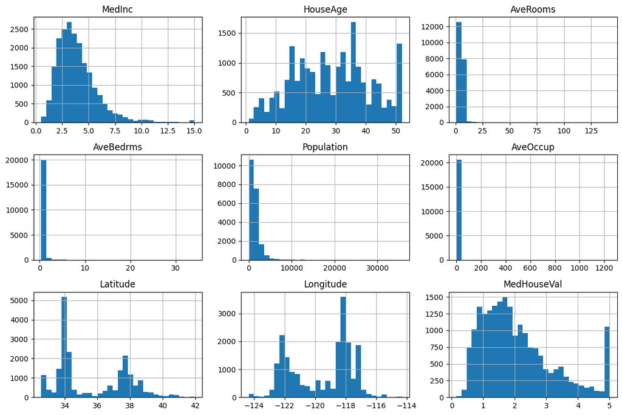

Generate one Boxenplot for each column (good for large datasets)

Example code:

for column in data_frame.columns: plt.figure(figsize=(6, 4)) sns.boxenplot(data=data_frame[column]) plt.title(f'Boxenplot for {column}') plt.show()

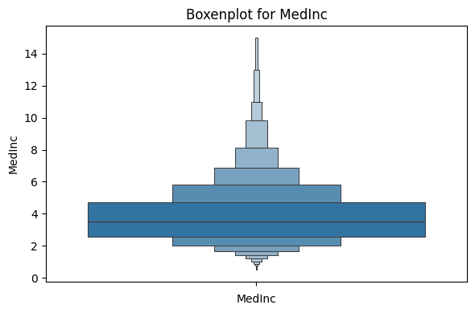

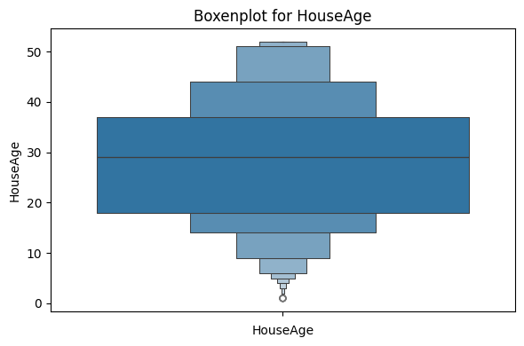

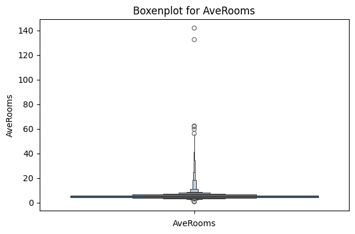

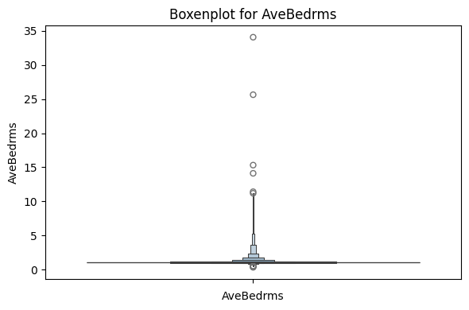

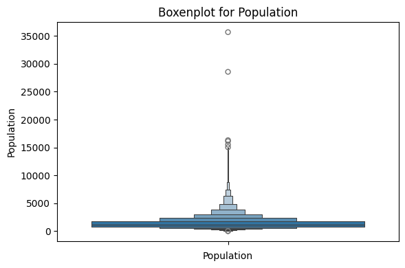

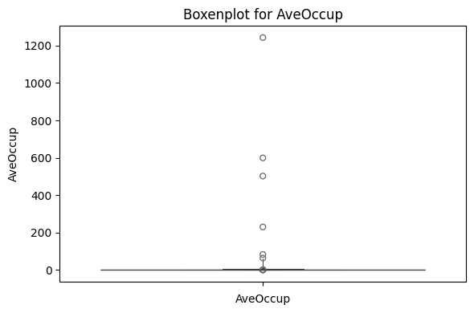

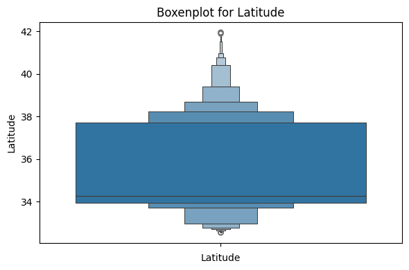

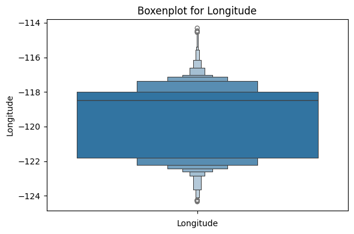

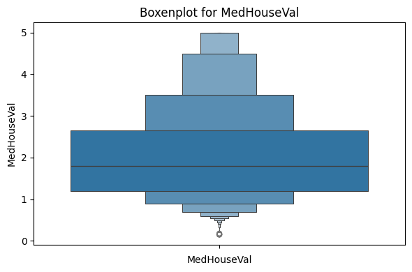

### Boxenplot Analysis

Third - Scatter Plots

Generate all Scatter plots (there is a LOT of data, so this will take a while)

Comment out after analysis to speed up the notebook.

Example code:

sns.pairplot(data_frame)

plt.show()

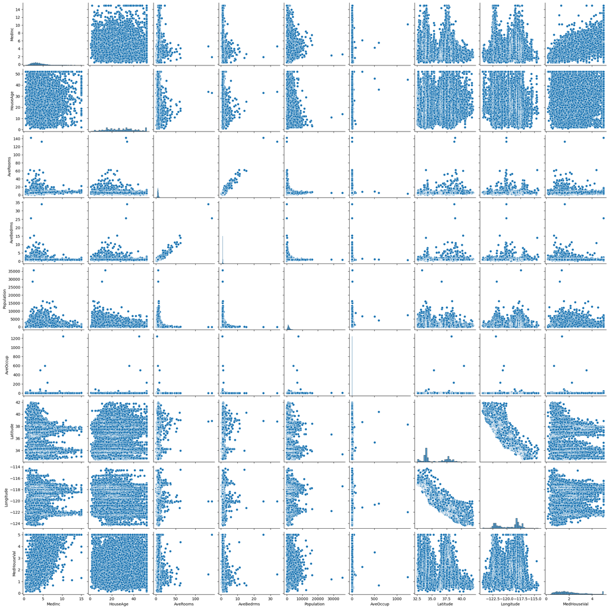

Analysis:

What patterns or anomalies do you see? Do any features stand out? Medinc shows strong positive correlation with Medhouseval. • Averooms has a weaker relationship but still contributes. • Population and AveOccup show outliers and skew. • Laatitude and Longitude reflect geographic spread

This is a Markdown Cell.

## Section 3. Feature Selection and Justification

### 3.1 Choose two input features for predicting the target

- Select `MedInc` and `AveRooms` as predictors.
- Select `MedHouseVal` as the target variable.

In the following, X is capitalized because it represents a matrix (consistent with mathematical notation). y is lowercase because it represents a vector (consistent with mathematical notation).

First:

- Create a list of contributing features and the target variable
- Define the target feature string (the variable we want to predict)
- Define the input DataFrame
- Define the output DataFrame

Example code:

features: list = ['MedInc', 'AveRooms']

target: str = 'MedHouseVal'

df_X = data_frame[features]

df_y = data_frame[target]

### Feature Selection Justification

- `MedInc` shows strong correlation with `MedHouseVal`, making it a reliable predictor.
- `AveRooms` reflects housing size and may influence price.
- These features are numeric, clean, and interpretable — ideal for a simple linear regression model.

## Section 4. Train a Linear Regression Model

### 4.1 Split the data

Split the dataset into training and test sets (80% train / 20% test).

Call train_test_split() by passing in:

- df_X – Feature matrix (input data) as a pandas DataFrame
- y – Target values as a pandas Series
- test_size – Fraction of data to use for testing (e.g., 0.1 = 10%)
- random_state – Seed value for reproducible splits

We'll get back four return values:

- X_train – Training set features (DataFrame)
- X_test – Test set features (DataFrame)
- y_train – Training set target values (Series)
- y_test – Test set target values (Series)

Example code:

X_train, X_test, y_train, y_test = train_test_split( df_X, df_y, test_size=0.2, random_state=42)

### Train-Test Split Justification

- 80/20 split ensures enough data for training while preserving a test set for evaluation.
- `random_state=42` ensures reproducibility across runs.
- This step prevents overfitting and allows us to assess generalization.

This is a Markdown Cell.

### 4.2 Train the model

Create and fit a `LinearRegression` model.

LinearRegression – A class from sklearn.linear_model that creates a linear regression model.

model – An instance of the LinearRegression model. This object will store the learned coefficients and intercept after training.

fit() – Trains the model by finding the best-fit line for the training data using the Ordinary Least Squares (OLS) method.

X_train – The input features used to train the model.

y_train – The target values used to train the model.

Example code:

model = LinearRegression()

model.fit(X_train, y_train)

```
LinearRegression()
```

### Model Training Summary

The model was trained using Ordinary Least Squares (OLS) on two features: `MedInc` and `AveRooms`. It has now learned the best-fit coefficients to predict `MedHouseVal`.

Make predictions for the test set.

The model.predict() method applies this equation to the X test data to compute predicted values.

y_pred = model.predict(X_test)

y_pred contains all the predicted values for all the rows in X_test based on the linear regression model.

Example code:

y_pred = model.predict(X_test)

### Prediction Summary

The model has generated predicted house values (`y_pred`) for the test set based on the learned relationship between `MedInc`, `AveRooms`, and `MedHouseVal`.

This is a Markdown Cell.

### 4.3 Report R^2, MAE, RMSE

Evaluate the model using R^2, MAE, and RMSE.

First:

- Coefficient of Determination (R^2) - This tells you how well the model explains the variation in the target variable. A value close to 1 means the model fits the data well; a value close to 0 means the model doesn’t explain the variation well.

Example code:

r2 = r2_score(y_test, y_pred)

print(f'R²: {r2:.2f}')

[output not shown]

### Evaluation Results

- **R² = 0.46** → The model explains 46% of the variance in house prices. This suggests a moderate fit, but there’s room for improvement.
- **MAE = 0.62** → On average, predictions are off by about $62,000 (since the target is in hundreds of thousands).
- **RMSE = 0.84** → Larger errors are penalized more heavily; this value indicates some variability in prediction accuracy.

Overall, the model captures general trends but may benefit from additional features or transformations to improve performance.

This is a Markdown Cell

Second:

- Mean Absolute Error (MAE) - This is the average of the absolute differences between the predicted values and the actual values. A smaller value means the model’s predictions are closer to the actual values.

Example code:

mae = mean_absolute_error(y_test, y_pred)

print(f'MAE: {mae:.2f}')

```
MAE: 0.62
```

This is a Markdown Cell

Third:

- Root Mean Squared Error (RMSE) - This is the square root of the average of the squared differences between the predicted values and the actual values. It gives a sense of how far the predictions are from the actual values, with larger errors having more impact.

Example code:

rmse = root_mean_squared_error(y_test, y_pred)

print(f'RMSE: {rmse:.2f}')

```
RMSE: 0.84
```

### RMSE Interpretation

An RMSE of **0.84** means the model's predictions deviate from actual house values by about $84,000 on average (since the target is in hundreds of thousands). This suggests moderate accuracy, with room for improvement through feature engineering or model tuning.

## Section 5: Conclusion - Model Evaluation: Actual vs Predicted House Values

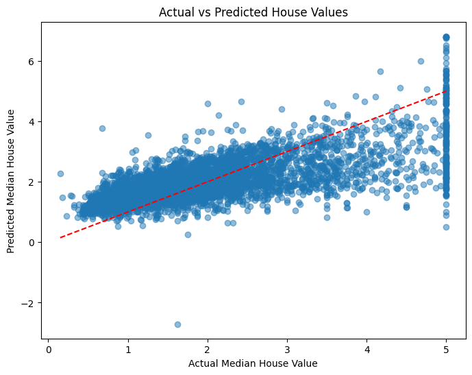

## Interpretation: Actual vs Predicted House Values

This scatter plot compares the actual median house values (`y_test`) with the predicted values from the regression model (`y_pred`). Each blue dot represents a test data point, and the red dashed line (`y = x`) serves as a reference for perfect predictions.

## Conclusion: Model Evaluation

The regression model demonstrates a reasonable ability to predict median house values. The scatter plot and previously calculated metrics (MAE and RMSE) confirm that the model captures general trends but has limitations in precision.